# CV4GS_01_jupyter-tutorial slides

**CV4GS - Jupyter Notebook tutorial**

In this tutorial, we will cover:

- Basic Jupyter notebook aspects: cell types, kernel, workflow, shortcuts
- Markdown syntax
- Magic commands to expand notebook functionalities
- Widgets
- Miscelaneous: converting notebooks, tunneling through SSH

### Table of Contents

# What is a Jupyter Notebook?

- a notebook is made up of **cells**. There are 3 main types of cells:
  - `Code cells`  
    ⇒ supports "Julia", "Python", or "R" languages (=**Ju**lia, **Pyt**hon, **R** )  
    ⇒ press esc+`y` to turn cell into code cell
  - `Markdown cells`  
    ⇒ uses the "Markdown" language to write text, add images, equations, etc.  
    ⇒ press esc+`m` to turn cell into markdown cell
  - `Raw cells` (rarely used)  
    ⇒ plain text  
    ⇒ press esc+`r` to turn cell into raw cell
- the notebook **kernel** is a "computational engine" that executes the code contained in a Notebook. Here we set a "Python 3" to excecute python code. (Kernels for many other languages exist).

## Code cell

The cell below is a `Code cell` (default type) with Python code.

Press `shift + return` to execute it. The result will get rendered beneath the cell.

```python
x = 1
y = 2
print(x+y)
```

```
3
```

Variables are shared between cells. Try executing the cell below:

```python
print(y + 2)
```

```
4
```

**Note:** Jupyter notebooks are expected to be run from top to bottom, so executing cells out of order can result in errors as variables may need undefined.

Figures will be plotted in the cell:

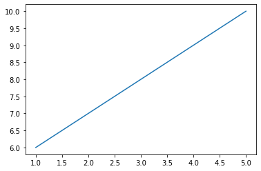

```python
from matplotlib import pyplot as plt
x = [1,2,3,4,5]
y = [6,7,8,9,10]
plt.plot(x, y)
```

## Markdown cell

[`Markdown`](https://en.wikipedia.org/wiki/Markdown) is a lightweight *markup language** for creating formatted text.

> "A *markup language* is a system for annotating a document in a way that is syntactically distinguishable from the text, meaning when the document is processed for display, the markup language is not shown, and is only used to format the text." ([wikipedia](https://en.wikipedia.org/wiki/Markup_language))  
> Examples: HTML, LaTeX, RTF, etc.

Key design goal of `Markdown` language is readability, ommiting obvious tags and formatting instructions like those used by HTML, RTF, etc.

**Important:** Press "M" key to convert cell into "Markdown cell"

## Jupyter keyboard shortcuts

- `Esc` & `Enter`: switch to command or edit mode
- `m` => switch cell to markdown type
- `y` => switch cell to code type
- `Shift-Enter`: execute cell, jump to cell below (or create a new one if last cell is selected)
- `Ctrl-Enter`: execute cell, insert new cell below
- `b` => add below the current one (Note you have to be in `esc` mode.)
- `a` => add above the current one (Note you have to be in `esc` mode.)
- `d+d` => delete cell (Note you have to be in `esc` mode.)
- `o` => hide/show cell output
- `ctrl+shift+minus`: split cell
- `shift+tab`: open documentation of a function
- `f`: find text in cell/notebook (Note you have to be in `esc` mode.)
- `alt+c`: comment code (if 'comment-uncomment' jupyter extension is enabled)
- `ctrl+\`: comment code (american keyboard layout)
- `ctrl+}`: comment code (latin american keyboard layout)
- `0+0` => restart notebook kernel the current one (Note you have to be in `esc` mode.)
- `ctrl+s` => save notebook

# Markdown syntax

The human-readable syntax allows to format text in many ways: make headings, emphasize text (bolding, italicizing, ...), creating numered/bulleted lists, add links, format mathematical symbols, make tables, etc.

Syntax reference: [link](https://www.markdownguide.org/basic-syntax/)

# IPython Magic commands

Magic commands are special commands which add special functionalities to the jupyter notebook interface.  
Below is a selection of some useful commands.

## lsmagic

```
List currently available magic functions.
```

```python
%lsmagic
```

```
Available line magics:
%alias  %alias_magic  %autoawait  %autocall  %automagic  %autosave  %bookmark  %cat  %cd  %clear  %colors  %conda  %config  %connect_info  %cp  %debug  %dhist  %dirs  %doctest_mode  %ed  %edit  %env  %gui  %hist  %history  %killbgscripts  %ldir  %less  %lf  %lk  %ll  %load  %load_ext  %loadpy  %logo…

Available cell magics:
%%!  %%HTML  %%SVG  %%bash  %%capture  %%debug  %%file  %%html  %%javascript  %%js  %%latex  %%markdown  %%perl  %%prun  %%pypy  %%python  %%python2  %%python3  %%ruby  %%script  %%sh  %%svg  %%sx  %%system  %%time  %%timeit  %%writefile

Automagic is ON, % prefix IS NOT needed for line magics.
```

## run file

```
Execute a python script.
```

```python
%run <my_script.py>
```

## load file

```
Insert code from an external file into cell.
```

```python
%load <my_script.py>
```

## writefile

```
Export the contents of a cell/Show the contents of an external script
```

```python
%%writefile pythoncode.py

import numpy
a = 1
b = 2

def add(x,y)
    return x+y

c = add(a, b)
```

```
Writing pythoncode.py
```

## time

```
Time the execution of the code.
```

```python
%time

import random
for i in range(0, 1000000):
    random.random()
```

```
CPU times: user 0 ns, sys: 0 ns, total: 0 ns
Wall time: 8.11 µs
```

## matplotlib display

```
Select how to display matlpotlib graphs.
```

**List the available backends:**  
Note: not all will work, it depends on your installation

```python
%matplotlib --list
```

```
Available matplotlib backends: ['tk', 'gtk', 'gtk3', 'wx', 'qt4', 'qt5', 'qt', 'osx', 'nbagg', 'notebook', 'agg', 'svg', 'pdf', 'ps', 'inline', 'ipympl', 'widget']
```

**Plot static figure embedded in notebook (default setting):**

```python
%matplotlib inline
```

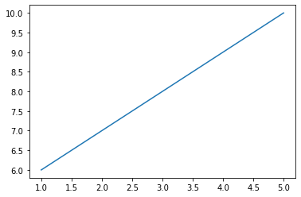

```python
from matplotlib import pyplot as plt
x = [1,2,3,4,5]
y = [6,7,8,9,10]
plt.plot(x, y)
```

**Plot interactive figure:**

```python
%matplotlib notebook
```

```python
from matplotlib import pyplot as plt
x = [1,2,3,4,5]
y = [6,7,8,9,10]
plt.plot(x, y)
```

## autoreload modules

```
Reload modules before executing user code.

%autoreload 0 => Disable automatic reloading.
%autoreload 1 => Reload all modules imported every time before executing the Python code typed.
%autoreload 2 => Reload all modules every time before executing the Python code typed
%aimport      => List modules which are to be automatically imported or not to be imported.
```

```python
%load_ext autoreload
%autoreload 2
```

```python
from foo import some_function
```

```python
# Run function
some_function()
```

```python
# Open foo.py in an editor and change some_function to return 43
```

```python
# Run function after edit => will reflect the changes and return 43
some_function()
```

## cython

Note: the following example requires to have the [cython](http://cython.readthedocs.io) package installed

- Cython is Python with C data types.
- Almost any Python code is also valid Cython
- Cython will compile Python to C (and then to machine code)
- Easily mix C and Python code
- Easy writing of wrappers for C code
- use cdefs and C types to type your code (only allowed at top level indentation)

```python
# --- Python implementation of primes():

def primes():
    result = []
    p = [0] * 1000
    kmax = 1000
    k = 0
    n = 2
    while k < kmax:
        i = 0
        while i < k and n % p[i] != 0:
            i = i + 1
        if i == k:
            p[k] = n
            k = k + 1
            result.append(n)
        n = n + 1
    return result
```

```python
%timeit primes()
```

```
58.4 ms ± 1.13 ms per loop (mean ± std. dev. of 7 runs, 10 loops each)
```

```python
# --- Cython implementation of primes():
```

```python
%load_ext Cython
```

```python
%%cython

def primes():
    cdef int n, k, i #<--- defines integer variables
    cdef int p[1000] #<--- defines integer array
    result = []

    cdef int kmax = 1000 #<---
    k = 0
    n = 2
    while k < kmax:
        i = 0
        while i < k and n % p[i] != 0:
            i = i + 1
        if i == k:
            p[k] = n
            k = k + 1
            result.append(n)
        n = n + 1
    return result
```

```python
%timeit primes()
```

```
2.16 ms ± 3.85 µs per loop (mean ± std. dev. of 7 runs, 100 loops each)
```

# Excecute system command

Example: list files in working directory

```python
!ls -la
```

Example: test python version, and cython package version

```python
!python --version
```

```python
!conda list | grep cython
```

Example: install additional package

```python
!conda install <package_name>
!pip install <package_name>
```

# Run code from a different kernel

IPython can run various Kernel in a cell: `bash`, `HTML`, `ruby`, `perl`, `python2`, `python3`, etc.

Example: run bash code

```python
%%bash
for i in {1..5}
do echo "i = $i"
done
```

```
i = 1
i = 2
i = 3
i = 4
i = 5
```

```python
%%python2
for i in xrange(5):
    print i
```

```
0
1
2
3
4
```

```python
%%python3
for i in range(5):
    print(i)
```

```
0
1
2
3
4
```

# Widgets

See: https://github.com/jupyter-widgets/tutorial

```python
import ipywidgets as widgets
```

## slider

```python
slider = widgets.FloatSlider(
    value=7.5,
    min=5.0,
    max=10.0,
    step=0.1,
    description='Input:',
)

slider
```

```
FloatSlider(value=7.5, description='Input:', max=10.0, min=5.0)
```

```python
print(slider.value)
```

```
7.5
```

## link widgets

EX: set slider, and display value in a text box.

```python
# Create text box to hold slider value
text = widgets.FloatText(description='Value')

# Link slider value and text box value
widgets.link((slider, 'value'), (text, 'value'))

# Put them in a vertical box
widgets.VBox([slider, text])
```

```
VBox(children=(FloatSlider(value=8.3, description='Input:', max=10.0, min=5.0), FloatText(value=8.3, descripti…
```

## widget interaction with function

```python
def f(x):
    print(x * x)
```

```python
widgets.interact(f, x=(0, 100));
```

```
interactive(children=(IntSlider(value=50, description='x'), Output()), _dom_classes=('widget-interact',))
```

```python
slider = widgets.FloatSlider(
    value=7.5,
    min=5.0,
    max=10.0,
    step=0.1,
    description='Input:',
)

# Create non-editable text area to display square of value
square_display = widgets.HTML(description="Square: ", value='{}'.format(slider.value**2))

# Create function to update square_display's value when slider changes
def update_square_display(change):
    square_display.value = '{}'.format(change.new**2)

slider.observe(update_square_display, names='value')

# Put them in a vertical box
widgets.VBox([slider, square_display])
```

```
VBox(children=(FloatSlider(value=7.5, description='Input:', max=10.0, min=5.0), HTML(value='56.25', descriptio…
```

## other Jupyter widget frameworks

- [bqplot](https://github.com/bqplot/bqplot/blob/master/examples/Index.ipynb) - 2d plotting library in which everything displayed is a widget
- ipympl - widget backend for [matplotlib](https://matplotlib.org/3.2.2/contents.html) graphics
- [pythreejs](https://pythreejs.readthedocs.io/en/stable/index.html) - low-level 3d graphics library
- [ipyvolume](https://ipyvolume.readthedocs.io/en/latest/) - 3d plotting and volume rendering
- [ipyleaflet](https://ipyleaflet.readthedocs.io/en/latest/)_ - interactive maps
- ipywebrtc - video streaming
- [ipysheet](https://ipysheet.readthedocs.io/en/latest/) - interactive spreadsheets
- ipytree - tree for viewing hierarchical material
- [ipycanvas](https://ipycanvas.readthedocs.io/en/latest/?badge=latest) - interactive drawing in a notebook
- [ipyevents](https://github.com/mwcraig/ipyevents/blob/master/doc/Widget%20DOM%20Events.ipynb) - capture mouse/keyboard events on a widget
- ...

Installation example (from terminal using Anaconda's package manager):

```
$ conda install -c conda-forge bqplot
```

Example: binary star simulation dashboard using `ipywidgets`, `pythreejs`, and `bqplot`: https://github.com/JuanCab/AstroInteractives

# Convert notebook

Notebooks can be converted to a number of formats, using the command from terminal: `jupter nbconvert --to <desired format> <notebook.ipynb>`

## Conversion to slides

1. In notebook:  
   => View > Cell toolbar > Slideshow
2. Select which cells should become slide, using the dropdown menu on the top right of each cell
3. Create slideshow from notebook running following command in terminal:

   ```
   $ jupyter nbconvert --to slides mynotebook.ipynb
   ```

   => a distinc file called "mynotebook.slides.html" will be generated in the same directory

# Connection to remote notebooks

## 1. connection using vscode

=> install extension "Remote - SSH"  
=> https://marketplace.visualstudio.com/items?itemName=ms-vscode-remote.remote-ssh

## 2. connection without vscode: tunneling through SSH

1. Log into remote computer through SSH

   ```
   $ ssh user@ip
   ```

2. In remote computer launch Jupyter with the --no-browser option:

   ```
   $ jupyter notebook --no-browser --port=8889
   ```

3. Open a second SSH connection with the remote computer, using the tunneling port specified above:

   ```
   $ ssh -L localhost:8888:localhost:8889 user@ip
   ```

4. Open a webrowser from your local computer and open Jupyter

   ```
    http://localhost:8888/tree/
   ```